# flotte Tunisair

### La distribution:

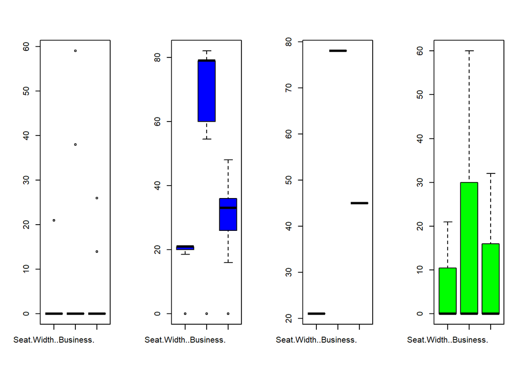

```r
par(mfrow=c(1,4))
b1=cluster1[,8:10]
boxplot(b1, col="red")
b2=cluster2[,8:10]
boxplot(b2,col="blue")
b3=cluster3[,8:10]
boxplot(b3,col="yellow")
b4=tn[,8:10]
boxplot(b4, col="green")
```

Dans cette partie on va étudier la distribution des différentes variables du Bisness Class. D’après les Boxplots On peut déduire que le cluster3 est le meilleur suivi du cluster 2, du celui de Tunisair et du cluster1 du point de vue largeur du siège, hauteur du siège et nombre de siège. On peut Conclure aussi que Tunisair conforme au cluster 1 dans ce critère.

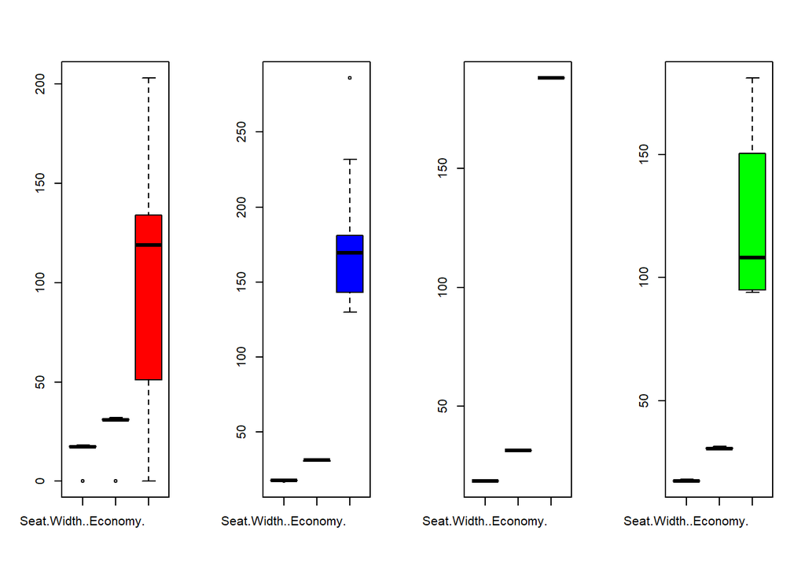

```r
par(mfrow=c(1,4))
b1=cluster1[,14:16]
boxplot(b1, col="red")
b2=cluster2[,14:16]
boxplot(b2,col="blue")
b3=cluster3[,14:16]
boxplot(b3,col="yellow")
b4=tn[,14:16]
boxplot(b4, col="green")
```

Dans cette partie on va étudier la distribution des différentes variables du Economy Class. D’après les Boxplots On peut déduire que le cluster3 est le meilleur suivi du cluster 2, du cluster 1 et du celui de Tunisair du point de vue largeur du siège, hauteur du siège et nombre de siège. On peut Conclure aussi que Tunisair conforme plus au cluster 1 dans ce critère.

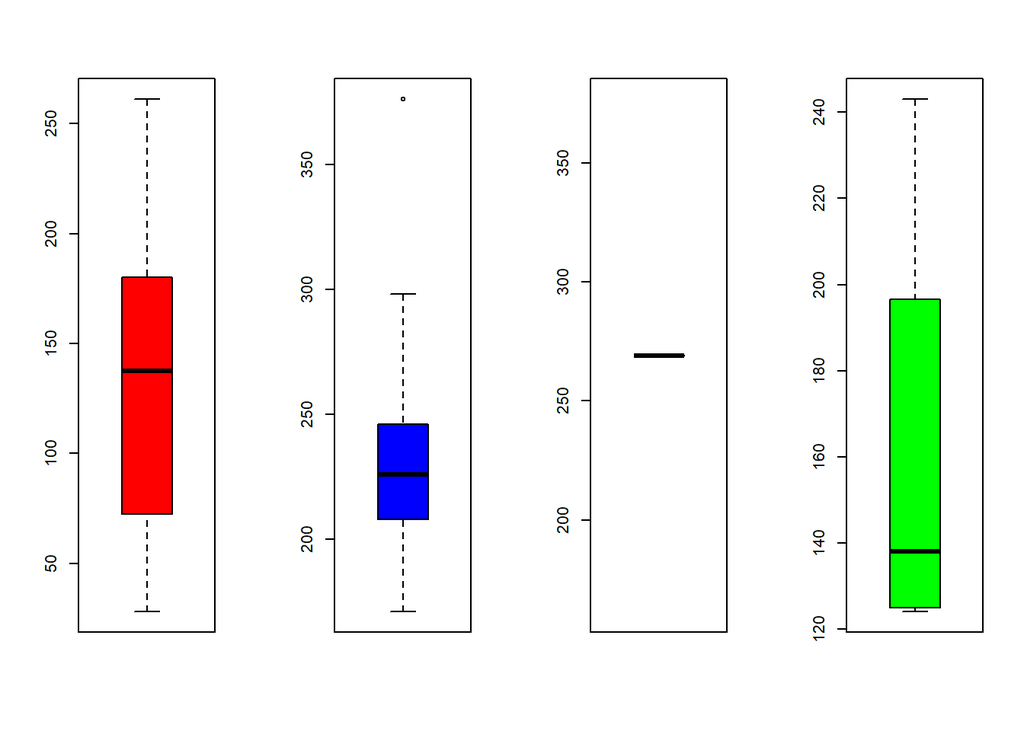

```r
par(mfrow=c(1,4))
b1=cluster1[,17]
boxplot(b1, col="red")
b2=cluster2[,17]
boxplot(b2,col="blue")
b3=cluster3[,17]
boxplot(b3,col="yellow")
b4=tn[,17]
boxplot(b4, col="green")
```

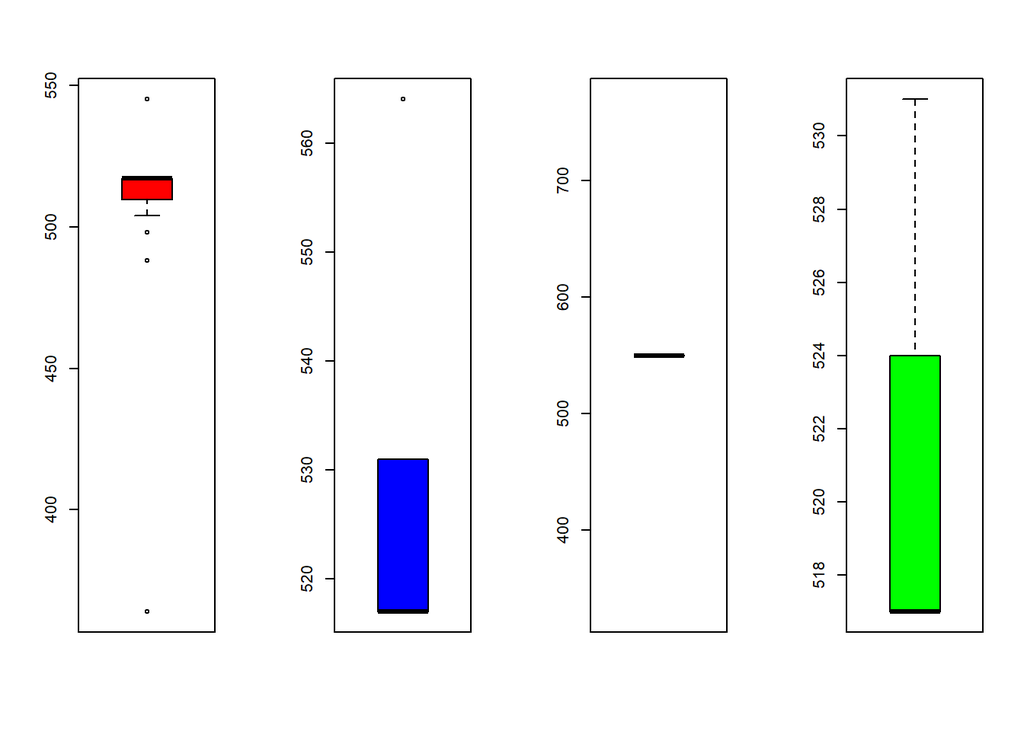

```r
par(mfrow=c(1,4))
b1=cluster1[,18]
boxplot(b1, col="red")
b2=cluster2[,18]
boxplot(b2,col="blue")
b3=cluster3[,18]
boxplot(b3,col="yellow")
b4=tn[,18]
boxplot(b4, col="green")
```

#### le profil typique des avions:

La majorité des avions sont classés dans le 1 er cluster d’où ce dernier représente le profil typique.

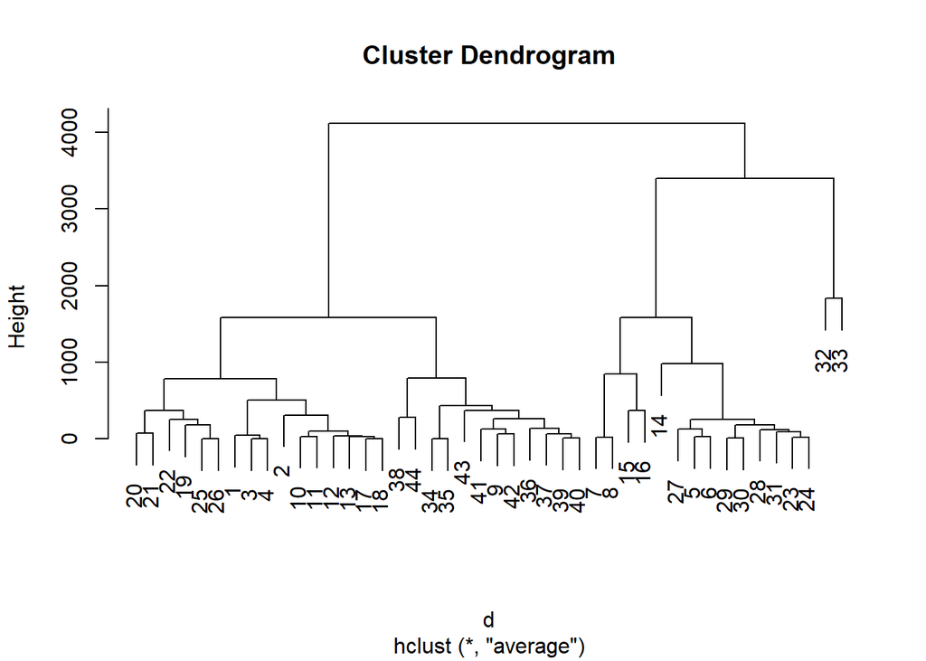

```r
c=delta[,2:34]
d=dist(c,method = "euclidean")
hc=hclust(d,method="average")
plot(hc)
```

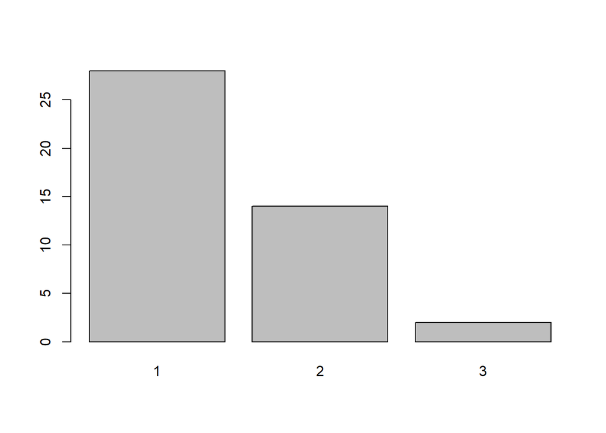

```r
gpe_cah=cutree(hc,3)

barplot(table(gpe_cah))
```

```r
table(gpe_cah)
```

```
## gpe_cah
##  1  2  3
## 28 14  2
```

```r
cluster1=data.frame()
n=length(gpe_cah)
for(i in 1:n) {
  if(gpe_cah[i]==1)
     {
      cluster1=rbind(cluster1,delta[i,])
     }
}
cluster1$Aircraft
```

```
##  [1] Airbus A319                  Airbus A319 VIP
##  [3] Airbus A320                  Airbus A320 32-R
##  [5] Boeing 717                   Boeing 737-700 (73W)
##  [7] Boeing 737-800 (738)         Boeing 737-800 (73H)
##  [9] Boeing 737-900ER (739)       Boeing 757-200 (75M)
## [11] Boeing 757-200 (75N)         Boeing 757-200 (757)
## [13] Boeing 757-200 (75V)         Boeing 757-200 (75X)
## [15] Boeing 757-300               Boeing 767-300 (76P)
## [17] Boeing 767-300 (76Q)         CRJ 100/200 Pinnacle/SkyWest
## [19] CRJ 100/200 ExpressJet       CRJ 700
## [21] CRJ 900                      E120
## [23] E170                         E175
## [25] ERJ-145                      MD-88
## [27] MD-90                        MD-DC9-50
## 44 Levels: Airbus A319 Airbus A319 VIP Airbus A320 ... MD-DC9-50
```

cluster1:

```r
moyenneCluster1= colMeans(cluster1[,c(2:34)] , na.rm = T)
moyenneCluster1
```

```
##        Seat.Width..Club.        Seat.Pitch..Club.              Seat..Club.
##             6.928571e-01             1.571429e+00             4.285714e-01
## Seat.Width..First.Class. Seat.Pitch..First.Class.      Seats..First.Class.
##             1.664286e+01             3.076786e+01             1.442857e+01
##    Seat.Width..Business.    Seat.Pitch..Business.         Seats..Business.
##             1.500000e+00             3.464286e+00             1.428571e+00
## Seat.Width..Eco.Comfort. Seat.Pitch..Eco.Comfort.      Seats..Eco.Comfort.
##             1.438929e+01             2.801786e+01             1.482143e+01
##     Seat.Width..Economy.     Seat.Pitch..Economy.          Seats..Economy.
##             1.689286e+01             3.001786e+01             1.030000e+02
##            Accommodation     Cruising.Speed..mph.            Range..miles.
##             1.328214e+02             5.090357e+02             2.374929e+03
##                  Engines            Wingspan..ft.         Tail.Height..ft.
##             2.000000e+00             1.073617e+02             3.570786e+01
##              Length..ft.                     Wifi                    Video
##             1.271124e+02             8.571429e-01             3.928571e-01
##                    Power                Satellite                 Flat.bed
##             3.571429e-01             2.142857e-01             0.000000e+00
##                  Sleeper                     Club              First.Class
##             0.000000e+00             3.571429e-02             8.214286e-01
##                 Business              Eco.Comfort                  Economy
##             7.142857e-02             8.214286e-01             9.642857e-01
```

```r
moyenneCluster1[23:33]
```

```
##        Wifi       Video       Power   Satellite    Flat.bed     Sleeper
##  0.85714286  0.39285714  0.35714286  0.21428571  0.00000000  0.00000000
##        Club First.Class    Business Eco.Comfort     Economy
##  0.03571429  0.82142857  0.07142857  0.82142857  0.96428571
```

On va ajuster les variables qualitatives pour determiner le profil le plus typique des avions.

```r
for (i in 23:33)
{
  if(moyenneCluster1[i]<0.5)
  {
    moyenneCluster1[i]=0
  }
  else
  {
    moyenneCluster1[i]=1
  }
}
moyenneCluster1
```

```
##        Seat.Width..Club.        Seat.Pitch..Club.              Seat..Club.
##                0.6928571                1.5714286                0.4285714
## Seat.Width..First.Class. Seat.Pitch..First.Class.      Seats..First.Class.
##               16.6428571               30.7678571               14.4285714
##    Seat.Width..Business.    Seat.Pitch..Business.         Seats..Business.
##                1.5000000                3.4642857                1.4285714
## Seat.Width..Eco.Comfort. Seat.Pitch..Eco.Comfort.      Seats..Eco.Comfort.
##               14.3892857               28.0178571               14.8214286
##     Seat.Width..Economy.     Seat.Pitch..Economy.          Seats..Economy.
##               16.8928571               30.0178571              103.0000000
##            Accommodation     Cruising.Speed..mph.            Range..miles.
##              132.8214286              509.0357143             2374.9285714
##                  Engines            Wingspan..ft.         Tail.Height..ft.
##                2.0000000              107.3616786               35.7078571
##              Length..ft.                     Wifi                    Video
##              127.1123929                1.0000000                0.0000000
##                    Power                Satellite                 Flat.bed
##                0.0000000                0.0000000                0.0000000
##                  Sleeper                     Club              First.Class
##                0.0000000                0.0000000                1.0000000
##                 Business              Eco.Comfort                  Economy
##                0.0000000                1.0000000                1.0000000
```

=> Tunisair possede 3 modeles typiques

# **5-Evaluation:**

Dans cette partie, On passe à la révision des data science goals : Notre modalisation respecte les objectifs métier qu’on a déjà préciser.

# **6-Conclusion et Perspectives:**

Apres l’étude des exigences et des normes (âge , taille , cout .) des flottes régionales et internationales , on a constaté que la flotte de Tunisair respecte les normes d’âge et cout mais en terme de nombre d’effectif , la flotte de Tunisair se distingue par sa taille réduite.

Donc selon notre étude on propose que Tunisair ajoute à sa flotte des avions qui dispose de différentes classes comme Airbus A330 , Airbus A321 (321) V1. D’ailleurs la compagnie aérienne nationale « Tunisair » est en phase de négociations avec le constructeur aéronautique européen «Airbus», et ce, dans le but d’avancer le délai de livraison de cinq avions de catégorie A330 avant l’année 2020.